# Risk Factor Analysis

## Outcome Variable

**Outcome Variable:** whz

## Predictor Variables

**Intervention Variable:** exclfeed6

**Adjustment Set:**

unadjusted

## Stratifying Variables

The analysis was stratified on these variable(s):

- agecat
- studyid
- country

## Data Summary

| agecat | studyid | country | exclfeed6 | n_cell | n |
| --- | --- | --- | --- | --- | --- |
| Birth | ki0047075b-MAL-ED | BANGLADESH | 1 | 53 | 219 |
| Birth | ki0047075b-MAL-ED | BANGLADESH | 0 | 166 | 219 |
| Birth | ki0047075b-MAL-ED | BRAZIL | 1 | 11 | 168 |
| Birth | ki0047075b-MAL-ED | BRAZIL | 0 | 157 | 168 |
| Birth | ki0047075b-MAL-ED | INDIA | 1 | 5 | 187 |
| Birth | ki0047075b-MAL-ED | INDIA | 0 | 182 | 187 |
| Birth | ki0047075b-MAL-ED | NEPAL | 1 | 11 | 165 |
| Birth | ki0047075b-MAL-ED | NEPAL | 0 | 154 | 165 |
| Birth | ki0047075b-MAL-ED | PERU | 1 | 10 | 249 |
| Birth | ki0047075b-MAL-ED | PERU | 0 | 239 | 249 |
| Birth | ki0047075b-MAL-ED | SOUTH AFRICA | 1 | 0 | 209 |
| Birth | ki0047075b-MAL-ED | SOUTH AFRICA | 0 | 209 | 209 |
| Birth | ki0047075b-MAL-ED | TANZANIA, UNITED REPUBLIC OF | 1 | 1 | 115 |
| Birth | ki0047075b-MAL-ED | TANZANIA, UNITED REPUBLIC OF | 0 | 114 | 115 |
| Birth | ki1000108-CMC-V-BCS-2002 | INDIA | 1 | 7 | 7 |
| Birth | ki1000108-CMC-V-BCS-2002 | INDIA | 0 | 0 | 7 |
| Birth | ki1000108-IRC | INDIA | 1 | 0 | 12 |
| Birth | ki1000108-IRC | INDIA | 0 | 12 | 12 |
| Birth | ki1000109-EE | PAKISTAN | 1 | 0 | 1 |
| Birth | ki1000109-EE | PAKISTAN | 0 | 1 | 1 |
| Birth | ki1000304b-SAS-CompFeed | INDIA | 1 | 45 | 47 |
| Birth | ki1000304b-SAS-CompFeed | INDIA | 0 | 2 | 47 |
| Birth | ki1101329-Keneba | GAMBIA | 1 | 451 | 1336 |
| Birth | ki1101329-Keneba | GAMBIA | 0 | 885 | 1336 |
| Birth | kiGH5241-JiVitA-3 | BANGLADESH | 1 | 12371 | 15420 |
| Birth | kiGH5241-JiVitA-3 | BANGLADESH | 0 | 3049 | 15420 |
| Birth | kiGH5241-JiVitA-4 | BANGLADESH | 1 | 519 | 633 |
| Birth | kiGH5241-JiVitA-4 | BANGLADESH | 0 | 114 | 633 |
| 6 months | ki0047075b-MAL-ED | BANGLADESH | 1 | 57 | 235 |
| 6 months | ki0047075b-MAL-ED | BANGLADESH | 0 | 178 | 235 |

[output cut: 64 more lines]

The following strata were considered:

- agecat: 24 months, studyid: ki0047075b-MAL-ED, country: BANGLADESH
- agecat: 24 months, studyid: ki0047075b-MAL-ED, country: BRAZIL
- agecat: 24 months, studyid: ki0047075b-MAL-ED, country: INDIA
- agecat: 24 months, studyid: ki0047075b-MAL-ED, country: NEPAL
- agecat: 24 months, studyid: ki0047075b-MAL-ED, country: PERU
- agecat: 24 months, studyid: ki0047075b-MAL-ED, country: SOUTH AFRICA
- agecat: 24 months, studyid: ki0047075b-MAL-ED, country: TANZANIA, UNITED REPUBLIC OF
- agecat: 24 months, studyid: ki1000108-CMC-V-BCS-2002, country: INDIA
- agecat: 24 months, studyid: ki1000108-IRC, country: INDIA
- agecat: 24 months, studyid: ki1017093b-PROVIDE, country: BANGLADESH
- agecat: 24 months, studyid: ki1101329-Keneba, country: GAMBIA
- agecat: 24 months, studyid: ki1113344-GMS-Nepal, country: NEPAL
- agecat: 24 months, studyid: ki1148112-LCNI-5, country: MALAWI
- agecat: 24 months, studyid: kiGH5241-JiVitA-3, country: BANGLADESH
- agecat: 24 months, studyid: kiGH5241-JiVitA-4, country: BANGLADESH
- agecat: 6 months, studyid: ki0047075b-MAL-ED, country: BANGLADESH
- agecat: 6 months, studyid: ki0047075b-MAL-ED, country: BRAZIL
- agecat: 6 months, studyid: ki0047075b-MAL-ED, country: INDIA
- agecat: 6 months, studyid: ki0047075b-MAL-ED, country: NEPAL
- agecat: 6 months, studyid: ki0047075b-MAL-ED, country: PERU
- agecat: 6 months, studyid: ki0047075b-MAL-ED, country: SOUTH AFRICA
- agecat: 6 months, studyid: ki0047075b-MAL-ED, country: TANZANIA, UNITED REPUBLIC OF
- agecat: 6 months, studyid: ki1000108-CMC-V-BCS-2002, country: INDIA
- agecat: 6 months, studyid: ki1000108-IRC, country: INDIA
- agecat: 6 months, studyid: ki1000109-EE, country: PAKISTAN
- agecat: 6 months, studyid: ki1000304b-SAS-CompFeed, country: INDIA
- agecat: 6 months, studyid: ki1000304b-SAS-FoodSuppl, country: INDIA
- agecat: 6 months, studyid: ki1017093b-PROVIDE, country: BANGLADESH
- agecat: 6 months, studyid: ki1101329-Keneba, country: GAMBIA
- agecat: 6 months, studyid: ki1113344-GMS-Nepal, country: NEPAL
- agecat: 6 months, studyid: ki1148112-LCNI-5, country: MALAWI
- agecat: 6 months, studyid: kiGH5241-JiVitA-3, country: BANGLADESH
- agecat: 6 months, studyid: kiGH5241-JiVitA-4, country: BANGLADESH
- agecat: Birth, studyid: ki0047075b-MAL-ED, country: BANGLADESH
- agecat: Birth, studyid: ki0047075b-MAL-ED, country: BRAZIL
- agecat: Birth, studyid: ki0047075b-MAL-ED, country: INDIA
- agecat: Birth, studyid: ki0047075b-MAL-ED, country: NEPAL
- agecat: Birth, studyid: ki0047075b-MAL-ED, country: PERU
- agecat: Birth, studyid: ki0047075b-MAL-ED, country: SOUTH AFRICA
- agecat: Birth, studyid: ki0047075b-MAL-ED, country: TANZANIA, UNITED REPUBLIC OF
- agecat: Birth, studyid: ki1000108-CMC-V-BCS-2002, country: INDIA
- agecat: Birth, studyid: ki1000108-IRC, country: INDIA
- agecat: Birth, studyid: ki1000109-EE, country: PAKISTAN
- agecat: Birth, studyid: ki1000304b-SAS-CompFeed, country: INDIA
- agecat: Birth, studyid: ki1101329-Keneba, country: GAMBIA
- agecat: Birth, studyid: kiGH5241-JiVitA-3, country: BANGLADESH
- agecat: Birth, studyid: kiGH5241-JiVitA-4, country: BANGLADESH

### Dropped Strata

Some strata were dropped due to rare outcomes:

- agecat: Birth, studyid: ki0047075b-MAL-ED, country: SOUTH AFRICA
- agecat: Birth, studyid: ki0047075b-MAL-ED, country: TANZANIA, UNITED REPUBLIC OF
- agecat: Birth, studyid: ki1000108-CMC-V-BCS-2002, country: INDIA
- agecat: Birth, studyid: ki1000108-IRC, country: INDIA
- agecat: Birth, studyid: ki1000109-EE, country: PAKISTAN
- agecat: Birth, studyid: ki1000304b-SAS-CompFeed, country: INDIA
- agecat: 6 months, studyid: ki0047075b-MAL-ED, country: SOUTH AFRICA
- agecat: 6 months, studyid: ki0047075b-MAL-ED, country: TANZANIA, UNITED REPUBLIC OF
- agecat: 6 months, studyid: ki1000108-CMC-V-BCS-2002, country: INDIA
- agecat: 6 months, studyid: ki1000108-IRC, country: INDIA
- agecat: 6 months, studyid: ki1000304b-SAS-FoodSuppl, country: INDIA
- agecat: 24 months, studyid: ki0047075b-MAL-ED, country: SOUTH AFRICA
- agecat: 24 months, studyid: ki0047075b-MAL-ED, country: TANZANIA, UNITED REPUBLIC OF
- agecat: 24 months, studyid: ki1000108-CMC-V-BCS-2002, country: INDIA
- agecat: 24 months, studyid: ki1000108-IRC, country: INDIA

## Methods Detail

We’re interested in the causal parameters $E[Y_a]$ for all values of $a \in \mathcal{A}$. These parameters represent the mean outcome if, possibly contrary to fact, we intervened to set all units to have $A=a$. Under the randomization and positivity assumptions, these are identified by the statistical parameters $\psi_a=E_W[E_{Y|A,W}(Y|A=a,W)]$. In addition, we’re interested in the mean of $Y$, $E[Y]$ under no intervention (the observed mean). We will estimate these parameters by using SuperLearner to fit the relevant likelihood factors – $E_{Y|A,W}(Y|A=a,W)$ and $p(A=a|W)$, and then updating our likelihood fit using a joint TMLE.

For unadjusted analyses ($W=\{\}$), initial likelihoods were estimated using Lrnr_glm to estimate the simple $E(Y|A)$ and Lrnr_mean to estimate $p(A)$. For adjusted analyses, a small library containing Lrnr_glmnet, Lrnr_xgboost, and Lrnr_mean was used.

Having estimated these parameters, we will then use the delta method to estimate relative risks and attributable risks relative to a prespecified baseline level of $A$.

# Results Detail

## Results Plots

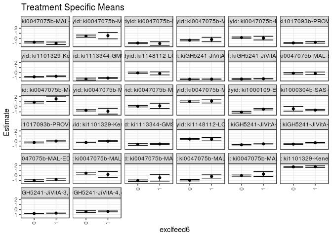

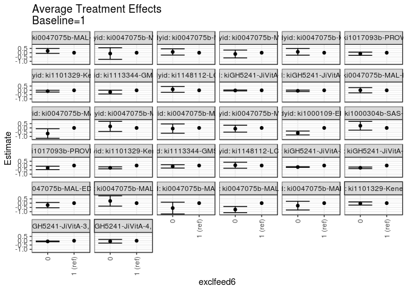

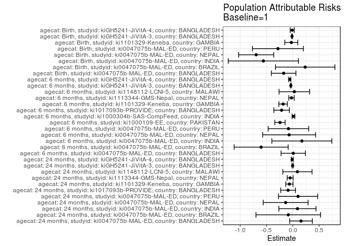

## Results Table

### Parameter: TSM

| agecat | studyid | country | intervention_level | baseline_level | estimate | ci_lower | ci_upper |
| --- | --- | --- | --- | --- | --- | --- | --- |
| Birth | ki0047075b-MAL-ED | BANGLADESH | 1 | NA | -0.8183019 | -1.0753209 | -0.5612829 |
| Birth | ki0047075b-MAL-ED | BANGLADESH | 0 | NA | -1.0481325 | -1.2158714 | -0.8803937 |
| Birth | ki0047075b-MAL-ED | BRAZIL | 1 | NA | 0.1718182 | -0.4001405 | 0.7437768 |
| Birth | ki0047075b-MAL-ED | BRAZIL | 0 | NA | 0.4238217 | 0.2309212 | 0.6167221 |
| Birth | ki0047075b-MAL-ED | INDIA | 1 | NA | -0.4840000 | -1.1529993 | 0.1849993 |
| Birth | ki0047075b-MAL-ED | INDIA | 0 | NA | -1.0589560 | -1.2040739 | -0.9138382 |
| Birth | ki0047075b-MAL-ED | NEPAL | 1 | NA | -0.2263636 | -0.5510782 | 0.0983510 |
| Birth | ki0047075b-MAL-ED | NEPAL | 0 | NA | -0.9723377 | -1.1178019 | -0.8268734 |
| Birth | ki0047075b-MAL-ED | PERU | 1 | NA | 0.2400000 | -0.2487497 | 0.7287497 |
| Birth | ki0047075b-MAL-ED | PERU | 0 | NA | -0.0549372 | -0.1747946 | 0.0649201 |
| Birth | ki1101329-Keneba | GAMBIA | 1 | NA | 1.7199778 | 1.5642674 | 1.8756883 |
| Birth | ki1101329-Keneba | GAMBIA | 0 | NA | 1.6753898 | 1.5752479 | 1.7755318 |
| Birth | kiGH5241-JiVitA-3 | BANGLADESH | 1 | NA | -0.7082831 | -0.7296333 | -0.6869329 |
| Birth | kiGH5241-JiVitA-3 | BANGLADESH | 0 | NA | -0.7847655 | -0.8250415 | -0.7444895 |
| Birth | kiGH5241-JiVitA-4 | BANGLADESH | 1 | NA | -0.3626590 | -0.4563353 | -0.2689826 |
| Birth | kiGH5241-JiVitA-4 | BANGLADESH | 0 | NA | -0.4250000 | -0.6164991 | -0.2335009 |
| 6 months | ki0047075b-MAL-ED | BANGLADESH | 1 | NA | -0.1541228 | -0.4186606 | 0.1104150 |
| 6 months | ki0047075b-MAL-ED | BANGLADESH | 0 | NA | -0.1440496 | -0.2955596 | 0.0074604 |
| 6 months | ki0047075b-MAL-ED | BRAZIL | 1 | NA | 1.5733333 | 1.0452289 | 2.1014378 |
| 6 months | ki0047075b-MAL-ED | BRAZIL | 0 | NA | 0.9218480 | 0.7512435 | 1.0924526 |
| 6 months | ki0047075b-MAL-ED | INDIA | 1 | NA | -0.8747222 | -1.4459598 | -0.3034846 |
| 6 months | ki0047075b-MAL-ED | INDIA | 0 | NA | -0.6983112 | -0.8261224 | -0.5705000 |
| 6 months | ki0047075b-MAL-ED | NEPAL | 1 | NA | 0.1870000 | -0.3320214 | 0.7060214 |
| 6 months | ki0047075b-MAL-ED | NEPAL | 0 | NA | 0.1119621 | -0.0238364 | 0.2477606 |
| 6 months | ki0047075b-MAL-ED | PERU | 1 | NA | 1.1386364 | 0.7571806 | 1.5200922 |
| 6 months | ki0047075b-MAL-ED | PERU | 0 | NA | 1.0518992 | 0.9245292 | 1.1792693 |
| 6 months | ki1000109-EE | PAKISTAN | 1 | NA | -0.4771591 | -0.6154207 | -0.3388974 |
| 6 months | ki1000109-EE | PAKISTAN | 0 | NA | -1.0655449 | -1.2435820 | -0.8875078 |
| 6 months | ki1000304b-SAS-CompFeed | INDIA | 1 | NA | -0.6469149 | -0.7835786 | -0.5102511 |
| 6 months | ki1000304b-SAS-CompFeed | INDIA | 0 | NA | -0.3968421 | -0.8495292 | 0.0558450 |
| 6 months | ki1017093b-PROVIDE | BANGLADESH | 1 | NA | 0.0048897 | -0.1614275 | 0.1712069 |
| 6 months | ki1017093b-PROVIDE | BANGLADESH | 0 | NA | -0.2734006 | -0.3704060 | -0.1763952 |
| 6 months | ki1101329-Keneba | GAMBIA | 1 | NA | -0.0152341 | -0.1135425 | 0.0830744 |
| 6 months | ki1101329-Keneba | GAMBIA | 0 | NA | -0.2815904 | -0.3446118 | -0.2185691 |
| 6 months | ki1113344-GMS-Nepal | NEPAL | 1 | NA | -0.5761386 | -0.6787486 | -0.4735286 |
| 6 months | ki1113344-GMS-Nepal | NEPAL | 0 | NA | -0.6736737 | -0.8424570 | -0.5048904 |
| 6 months | ki1148112-LCNI-5 | MALAWI | 1 | NA | 0.3640426 | 0.0368426 | 0.6912425 |
| 6 months | ki1148112-LCNI-5 | MALAWI | 0 | NA | 0.3987556 | 0.2722028 | 0.5253083 |
| 6 months | kiGH5241-JiVitA-3 | BANGLADESH | 1 | NA | -0.5556538 | -0.5771516 | -0.5341560 |
| 6 months | kiGH5241-JiVitA-3 | BANGLADESH | 0 | NA | -0.7345835 | -0.7763581 | -0.6928088 |
| 6 months | kiGH5241-JiVitA-4 | BANGLADESH | 1 | NA | -0.3389406 | -0.3853973 | -0.2924840 |
| 6 months | kiGH5241-JiVitA-4 | BANGLADESH | 0 | NA | -0.6023832 | -0.6803423 | -0.5244241 |
| 24 months | ki0047075b-MAL-ED | BANGLADESH | 1 | NA | -0.9871698 | -1.2391220 | -0.7352176 |
| 24 months | ki0047075b-MAL-ED | BANGLADESH | 0 | NA | -0.7787179 | -0.9186009 | -0.6388350 |
| 24 months | ki0047075b-MAL-ED | BRAZIL | 1 | NA | 0.5330000 | -0.1049931 | 1.1709931 |
| 24 months | ki0047075b-MAL-ED | BRAZIL | 0 | NA | 0.4382143 | 0.2220313 | 0.6543973 |
| 24 months | ki0047075b-MAL-ED | INDIA | 1 | NA | -1.0270000 | -1.3699520 | -0.6840480 |
| 24 months | ki0047075b-MAL-ED | INDIA | 0 | NA | -0.9370776 | -1.0552061 | -0.8189492 |
| 24 months | ki0047075b-MAL-ED | NEPAL | 1 | NA | -0.2336667 | -0.6744296 | 0.2070963 |
| 24 months | ki0047075b-MAL-ED | NEPAL | 0 | NA | -0.3799764 | -0.4970640 | -0.2628888 |
| 24 months | ki0047075b-MAL-ED | PERU | 1 | NA | 0.0437500 | -0.3245346 | 0.4120346 |
| 24 months | ki0047075b-MAL-ED | PERU | 0 | NA | 0.1471842 | 0.0256636 | 0.2687048 |
| 24 months | ki1017093b-PROVIDE | BANGLADESH | 1 | NA | -0.7984028 | -0.9580968 | -0.6387087 |
| 24 months | ki1017093b-PROVIDE | BANGLADESH | 0 | NA | -0.9176498 | -1.0143887 | -0.8209108 |
| 24 months | ki1101329-Keneba | GAMBIA | 1 | NA | -0.7381832 | -0.8224240 | -0.6539424 |
| 24 months | ki1101329-Keneba | GAMBIA | 0 | NA | -0.8366685 | -0.8987548 | -0.7745822 |
| 24 months | ki1113344-GMS-Nepal | NEPAL | 1 | NA | -1.0861096 | -1.1854287 | -0.9867904 |
| 24 months | ki1113344-GMS-Nepal | NEPAL | 0 | NA | -1.2890556 | -1.4888422 | -1.0892689 |
| 24 months | ki1148112-LCNI-5 | MALAWI | 1 | NA | -0.1644118 | -0.4639022 | 0.1350787 |
| 24 months | ki1148112-LCNI-5 | MALAWI | 0 | NA | -0.0573333 | -0.2193784 | 0.1047117 |
| 24 months | kiGH5241-JiVitA-3 | BANGLADESH | 1 | NA | -1.2956272 | -1.3220740 | -1.2691804 |
| 24 months | kiGH5241-JiVitA-3 | BANGLADESH | 0 | NA | -1.3115652 | -1.3597905 | -1.2633399 |
| 24 months | kiGH5241-JiVitA-4 | BANGLADESH | 1 | NA | -1.2216340 | -1.2588759 | -1.1843921 |
| 24 months | kiGH5241-JiVitA-4 | BANGLADESH | 0 | NA | -1.2778484 | -1.3547104 | -1.2009864 |

### Parameter: E(Y)

| agecat | studyid | country | intervention_level | baseline_level | estimate | ci_lower | ci_upper |
| --- | --- | --- | --- | --- | --- | --- | --- |
| Birth | ki0047075b-MAL-ED | BANGLADESH | NA | NA | -0.9925114 | -1.1346572 | -0.8503656 |
| Birth | ki0047075b-MAL-ED | BRAZIL | NA | NA | 0.4073214 | 0.2229599 | 0.5916830 |
| Birth | ki0047075b-MAL-ED | INDIA | NA | NA | -1.0435829 | -1.1865715 | -0.9005943 |
| Birth | ki0047075b-MAL-ED | NEPAL | NA | NA | -0.9226061 | -1.0630064 | -0.7822058 |
| Birth | ki0047075b-MAL-ED | PERU | NA | NA | -0.0430924 | -0.1600210 | 0.0738362 |
| Birth | ki1101329-Keneba | GAMBIA | NA | NA | 1.6904416 | 1.6057966 | 1.7750867 |
| Birth | kiGH5241-JiVitA-3 | BANGLADESH | NA | NA | -0.7234060 | -0.7433920 | -0.7034200 |
| Birth | kiGH5241-JiVitA-4 | BANGLADESH | NA | NA | -0.3738863 | -0.4580087 | -0.2897638 |
| 6 months | ki0047075b-MAL-ED | BANGLADESH | NA | NA | -0.1464929 | -0.2779745 | -0.0150113 |
| 6 months | ki0047075b-MAL-ED | BRAZIL | NA | NA | 0.9717225 | 0.8073791 | 1.1360658 |
| 6 months | ki0047075b-MAL-ED | INDIA | NA | NA | -0.7028736 | -0.8283047 | -0.5774424 |
| 6 months | ki0047075b-MAL-ED | NEPAL | NA | NA | 0.1167518 | -0.0146454 | 0.2481490 |
| 6 months | ki0047075b-MAL-ED | PERU | NA | NA | 1.0554461 | 0.9322755 | 1.1786167 |
| 6 months | ki1000109-EE | PAKISTAN | NA | NA | -0.7212766 | -0.8346857 | -0.6078675 |
| 6 months | ki1000304b-SAS-CompFeed | INDIA | NA | NA | -0.6348861 | -0.7630511 | -0.5067211 |
| 6 months | ki1017093b-PROVIDE | BANGLADESH | NA | NA | -0.2083706 | -0.2927992 | -0.1239419 |
| 6 months | ki1101329-Keneba | GAMBIA | NA | NA | -0.1997850 | -0.2531586 | -0.1464114 |
| 6 months | ki1113344-GMS-Nepal | NEPAL | NA | NA | -0.6015049 | -0.6892785 | -0.5137313 |
| 6 months | ki1148112-LCNI-5 | MALAWI | NA | NA | 0.3927574 | 0.2737700 | 0.5117448 |
| 6 months | kiGH5241-JiVitA-3 | BANGLADESH | NA | NA | -0.5931801 | -0.6126929 | -0.5736674 |
| 6 months | kiGH5241-JiVitA-4 | BANGLADESH | NA | NA | -0.3971948 | -0.4378192 | -0.3565704 |
| 24 months | ki0047075b-MAL-ED | BANGLADESH | NA | NA | -0.8315789 | -0.9546058 | -0.7085521 |
| 24 months | ki0047075b-MAL-ED | BRAZIL | NA | NA | 0.4466272 | 0.2416144 | 0.6516401 |
| 24 months | ki0047075b-MAL-ED | INDIA | NA | NA | -0.9390848 | -1.0545919 | -0.8235777 |
| 24 months | ki0047075b-MAL-ED | NEPAL | NA | NA | -0.3703084 | -0.4835704 | -0.2570464 |
| 24 months | ki0047075b-MAL-ED | PERU | NA | NA | 0.1430051 | 0.0254144 | 0.2605957 |
| 24 months | ki1017093b-PROVIDE | BANGLADESH | NA | NA | -0.8879412 | -0.9708680 | -0.8050144 |
| 24 months | ki1101329-Keneba | GAMBIA | NA | NA | -0.8032329 | -0.8532842 | -0.7531817 |
| 24 months | ki1113344-GMS-Nepal | NEPAL | NA | NA | -1.1369520 | -1.2269975 | -1.0469065 |
| 24 months | ki1148112-LCNI-5 | MALAWI | NA | NA | -0.0771196 | -0.2204715 | 0.0662323 |
| 24 months | kiGH5241-JiVitA-3 | BANGLADESH | NA | NA | -1.2991319 | -1.3225545 | -1.2757094 |
| 24 months | kiGH5241-JiVitA-4 | BANGLADESH | NA | NA | -1.2337581 | -1.2679680 | -1.1995482 |

### Parameter: ATE

| agecat | studyid | country | intervention_level | baseline_level | estimate | ci_lower | ci_upper |
| --- | --- | --- | --- | --- | --- | --- | --- |
| Birth | ki0047075b-MAL-ED | BANGLADESH | 1 | 1 | 0.0000000 | 0.0000000 | 0.0000000 |
| Birth | ki0047075b-MAL-ED | BANGLADESH | 0 | 1 | -0.2298306 | -0.5367428 | 0.0770815 |
| Birth | ki0047075b-MAL-ED | BRAZIL | 1 | 1 | 0.0000000 | 0.0000000 | 0.0000000 |
| Birth | ki0047075b-MAL-ED | BRAZIL | 0 | 1 | 0.2520035 | -0.3516084 | 0.8556153 |
| Birth | ki0047075b-MAL-ED | INDIA | 1 | 1 | 0.0000000 | 0.0000000 | 0.0000000 |
| Birth | ki0047075b-MAL-ED | INDIA | 0 | 1 | -0.5749560 | -1.2595138 | 0.1096017 |
| Birth | ki0047075b-MAL-ED | NEPAL | 1 | 1 | 0.0000000 | 0.0000000 | 0.0000000 |
| Birth | ki0047075b-MAL-ED | NEPAL | 0 | 1 | -0.7459740 | -1.1017821 | -0.3901659 |
| Birth | ki0047075b-MAL-ED | PERU | 1 | 1 | 0.0000000 | 0.0000000 | 0.0000000 |
| Birth | ki0047075b-MAL-ED | PERU | 0 | 1 | -0.2949372 | -0.7981688 | 0.2082944 |
| Birth | ki1101329-Keneba | GAMBIA | 1 | 1 | 0.0000000 | 0.0000000 | 0.0000000 |
| Birth | ki1101329-Keneba | GAMBIA | 0 | 1 | -0.0445880 | -0.2297208 | 0.1405448 |
| Birth | kiGH5241-JiVitA-3 | BANGLADESH | 1 | 1 | 0.0000000 | 0.0000000 | 0.0000000 |
| Birth | kiGH5241-JiVitA-3 | BANGLADESH | 0 | 1 | -0.0764824 | -0.1189659 | -0.0339989 |
| Birth | kiGH5241-JiVitA-4 | BANGLADESH | 1 | 1 | 0.0000000 | 0.0000000 | 0.0000000 |
| Birth | kiGH5241-JiVitA-4 | BANGLADESH | 0 | 1 | -0.0623410 | -0.2753804 | 0.1506984 |
| 6 months | ki0047075b-MAL-ED | BANGLADESH | 1 | 1 | 0.0000000 | 0.0000000 | 0.0000000 |
| 6 months | ki0047075b-MAL-ED | BANGLADESH | 0 | 1 | 0.0100732 | -0.2947801 | 0.3149265 |
| 6 months | ki0047075b-MAL-ED | BRAZIL | 1 | 1 | 0.0000000 | 0.0000000 | 0.0000000 |
| 6 months | ki0047075b-MAL-ED | BRAZIL | 0 | 1 | -0.6514853 | -1.2064630 | -0.0965076 |
| 6 months | ki0047075b-MAL-ED | INDIA | 1 | 1 | 0.0000000 | 0.0000000 | 0.0000000 |
| 6 months | ki0047075b-MAL-ED | INDIA | 0 | 1 | 0.1764110 | -0.4089505 | 0.7617725 |
| 6 months | ki0047075b-MAL-ED | NEPAL | 1 | 1 | 0.0000000 | 0.0000000 | 0.0000000 |
| 6 months | ki0047075b-MAL-ED | NEPAL | 0 | 1 | -0.0750379 | -0.6115307 | 0.4614549 |
| 6 months | ki0047075b-MAL-ED | PERU | 1 | 1 | 0.0000000 | 0.0000000 | 0.0000000 |
| 6 months | ki0047075b-MAL-ED | PERU | 0 | 1 | -0.0867371 | -0.4888959 | 0.3154216 |
| 6 months | ki1000109-EE | PAKISTAN | 1 | 1 | 0.0000000 | 0.0000000 | 0.0000000 |
| 6 months | ki1000109-EE | PAKISTAN | 0 | 1 | -0.5883858 | -0.8138042 | -0.3629673 |
| 6 months | ki1000304b-SAS-CompFeed | INDIA | 1 | 1 | 0.0000000 | 0.0000000 | 0.0000000 |
| 6 months | ki1000304b-SAS-CompFeed | INDIA | 0 | 1 | 0.2500728 | -0.2551626 | 0.7553082 |
| 6 months | ki1017093b-PROVIDE | BANGLADESH | 1 | 1 | 0.0000000 | 0.0000000 | 0.0000000 |
| 6 months | ki1017093b-PROVIDE | BANGLADESH | 0 | 1 | -0.2782903 | -0.4708298 | -0.0857508 |
| 6 months | ki1101329-Keneba | GAMBIA | 1 | 1 | 0.0000000 | 0.0000000 | 0.0000000 |
| 6 months | ki1101329-Keneba | GAMBIA | 0 | 1 | -0.2663564 | -0.3831307 | -0.1495820 |
| 6 months | ki1113344-GMS-Nepal | NEPAL | 1 | 1 | 0.0000000 | 0.0000000 | 0.0000000 |
| 6 months | ki1113344-GMS-Nepal | NEPAL | 0 | 1 | -0.0975351 | -0.2950614 | 0.0999912 |
| 6 months | ki1148112-LCNI-5 | MALAWI | 1 | 1 | 0.0000000 | 0.0000000 | 0.0000000 |
| 6 months | ki1148112-LCNI-5 | MALAWI | 0 | 1 | 0.0347130 | -0.3161080 | 0.3855340 |
| 6 months | kiGH5241-JiVitA-3 | BANGLADESH | 1 | 1 | 0.0000000 | 0.0000000 | 0.0000000 |
| 6 months | kiGH5241-JiVitA-3 | BANGLADESH | 0 | 1 | -0.1789297 | -0.2247760 | -0.1330833 |
| 6 months | kiGH5241-JiVitA-4 | BANGLADESH | 1 | 1 | 0.0000000 | 0.0000000 | 0.0000000 |
| 6 months | kiGH5241-JiVitA-4 | BANGLADESH | 0 | 1 | -0.2634426 | -0.3527725 | -0.1741127 |
| 24 months | ki0047075b-MAL-ED | BANGLADESH | 1 | 1 | 0.0000000 | 0.0000000 | 0.0000000 |
| 24 months | ki0047075b-MAL-ED | BANGLADESH | 0 | 1 | 0.2084519 | -0.0797271 | 0.4966309 |
| 24 months | ki0047075b-MAL-ED | BRAZIL | 1 | 1 | 0.0000000 | 0.0000000 | 0.0000000 |
| 24 months | ki0047075b-MAL-ED | BRAZIL | 0 | 1 | -0.0947857 | -0.7684104 | 0.5788390 |
| 24 months | ki0047075b-MAL-ED | INDIA | 1 | 1 | 0.0000000 | 0.0000000 | 0.0000000 |
| 24 months | ki0047075b-MAL-ED | INDIA | 0 | 1 | 0.0899224 | -0.2728040 | 0.4526487 |
| 24 months | ki0047075b-MAL-ED | NEPAL | 1 | 1 | 0.0000000 | 0.0000000 | 0.0000000 |
| 24 months | ki0047075b-MAL-ED | NEPAL | 0 | 1 | -0.1463097 | -0.6023596 | 0.3097401 |
| 24 months | ki0047075b-MAL-ED | PERU | 1 | 1 | 0.0000000 | 0.0000000 | 0.0000000 |
| 24 months | ki0047075b-MAL-ED | PERU | 0 | 1 | 0.1034342 | -0.2843812 | 0.4912496 |
| 24 months | ki1017093b-PROVIDE | BANGLADESH | 1 | 1 | 0.0000000 | 0.0000000 | 0.0000000 |
| 24 months | ki1017093b-PROVIDE | BANGLADESH | 0 | 1 | -0.1192470 | -0.3059570 | 0.0674630 |
| 24 months | ki1101329-Keneba | GAMBIA | 1 | 1 | 0.0000000 | 0.0000000 | 0.0000000 |
| 24 months | ki1101329-Keneba | GAMBIA | 0 | 1 | -0.0984853 | -0.2031334 | 0.0061628 |
| 24 months | ki1113344-GMS-Nepal | NEPAL | 1 | 1 | 0.0000000 | 0.0000000 | 0.0000000 |
| 24 months | ki1113344-GMS-Nepal | NEPAL | 0 | 1 | -0.2029460 | -0.4260581 | 0.0201661 |
| 24 months | ki1148112-LCNI-5 | MALAWI | 1 | 1 | 0.0000000 | 0.0000000 | 0.0000000 |
| 24 months | ki1148112-LCNI-5 | MALAWI | 0 | 1 | 0.1070784 | -0.2334405 | 0.4475973 |
| 24 months | kiGH5241-JiVitA-3 | BANGLADESH | 1 | 1 | 0.0000000 | 0.0000000 | 0.0000000 |
| 24 months | kiGH5241-JiVitA-3 | BANGLADESH | 0 | 1 | -0.0159380 | -0.0703716 | 0.0384955 |
| 24 months | kiGH5241-JiVitA-4 | BANGLADESH | 1 | 1 | 0.0000000 | 0.0000000 | 0.0000000 |
| 24 months | kiGH5241-JiVitA-4 | BANGLADESH | 0 | 1 | -0.0562144 | -0.1402054 | 0.0277765 |

### Parameter: PAR

| agecat | studyid | country | intervention_level | baseline_level | estimate | ci_lower | ci_upper |
| --- | --- | --- | --- | --- | --- | --- | --- |
| Birth | ki0047075b-MAL-ED | BANGLADESH | 1 | NA | -0.1742095 | -0.4072128 | 0.0587938 |
| Birth | ki0047075b-MAL-ED | BRAZIL | 1 | NA | 0.2355032 | -0.3286656 | 0.7996721 |
| Birth | ki0047075b-MAL-ED | INDIA | 1 | NA | -0.5595829 | -1.2259702 | 0.1068045 |
| Birth | ki0047075b-MAL-ED | NEPAL | 1 | NA | -0.6962424 | -1.0295489 | -0.3629360 |
| Birth | ki0047075b-MAL-ED | PERU | 1 | NA | -0.2830924 | -0.7661676 | 0.1999829 |
| Birth | ki1101329-Keneba | GAMBIA | 1 | NA | -0.0295362 | -0.1521780 | 0.0931056 |
| Birth | kiGH5241-JiVitA-3 | BANGLADESH | 1 | NA | -0.0151229 | -0.0235540 | -0.0066918 |
| Birth | kiGH5241-JiVitA-4 | BANGLADESH | 1 | NA | -0.0112273 | -0.0496261 | 0.0271715 |
| 6 months | ki0047075b-MAL-ED | BANGLADESH | 1 | NA | 0.0076299 | -0.2232809 | 0.2385407 |
| 6 months | ki0047075b-MAL-ED | BRAZIL | 1 | NA | -0.6016108 | -1.1146426 | -0.0885791 |
| 6 months | ki0047075b-MAL-ED | INDIA | 1 | NA | 0.1718487 | -0.3983856 | 0.7420829 |
| 6 months | ki0047075b-MAL-ED | NEPAL | 1 | NA | -0.0702482 | -0.5725023 | 0.4320058 |
| 6 months | ki0047075b-MAL-ED | PERU | 1 | NA | -0.0831903 | -0.4689093 | 0.3025288 |
| 6 months | ki1000109-EE | PAKISTAN | 1 | NA | -0.2441175 | -0.3421368 | -0.1460982 |
| 6 months | ki1000304b-SAS-CompFeed | INDIA | 1 | NA | 0.0120288 | -0.0145556 | 0.0386132 |
| 6 months | ki1017093b-PROVIDE | BANGLADESH | 1 | NA | -0.2132603 | -0.3611181 | -0.0654024 |
| 6 months | ki1101329-Keneba | GAMBIA | 1 | NA | -0.1845509 | -0.2656483 | -0.1034535 |
| 6 months | ki1113344-GMS-Nepal | NEPAL | 1 | NA | -0.0253663 | -0.0768630 | 0.0261305 |
| 6 months | ki1148112-LCNI-5 | MALAWI | 1 | NA | 0.0287148 | -0.2614906 | 0.3189202 |
| 6 months | kiGH5241-JiVitA-3 | BANGLADESH | 1 | NA | -0.0375264 | -0.0471659 | -0.0278868 |
| 6 months | kiGH5241-JiVitA-4 | BANGLADESH | 1 | NA | -0.0582542 | -0.0787304 | -0.0377780 |
| 24 months | ki0047075b-MAL-ED | BANGLADESH | 1 | NA | 0.1555909 | -0.0598620 | 0.3710438 |
| 24 months | ki0047075b-MAL-ED | BRAZIL | 1 | NA | -0.0863728 | -0.7002218 | 0.5274763 |
| 24 months | ki0047075b-MAL-ED | INDIA | 1 | NA | 0.0879152 | -0.2657473 | 0.4415777 |
| 24 months | ki0047075b-MAL-ED | NEPAL | 1 | NA | -0.1366417 | -0.5625825 | 0.2892991 |
| 24 months | ki0047075b-MAL-ED | PERU | 1 | NA | 0.0992551 | -0.2729019 | 0.4714120 |
| 24 months | ki1017093b-PROVIDE | BANGLADESH | 1 | NA | -0.0895384 | -0.2297955 | 0.0507187 |
| 24 months | ki1101329-Keneba | GAMBIA | 1 | NA | -0.0650497 | -0.1342099 | 0.0041105 |
| 24 months | ki1113344-GMS-Nepal | NEPAL | 1 | NA | -0.0508424 | -0.1072901 | 0.0056053 |
| 24 months | ki1148112-LCNI-5 | MALAWI | 1 | NA | 0.0872922 | -0.1903700 | 0.3649544 |
| 24 months | kiGH5241-JiVitA-3 | BANGLADESH | 1 | NA | -0.0035048 | -0.0154705 | 0.0084610 |
| 24 months | kiGH5241-JiVitA-4 | BANGLADESH | 1 | NA | -0.0121241 | -0.0303004 | 0.0060521 |